# Research Questions

**What is the distribution of the number of steps in sessions?**

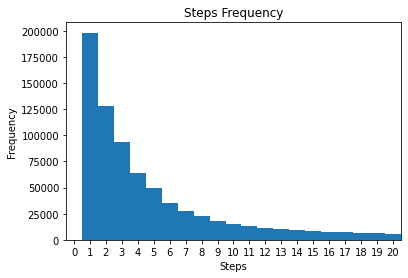

```python
bin_size = 1
sessions_steps = train.groupby('session_id', sort=False).timestamp.count()
bin_edges = np.arange(0, sessions_steps.max() + bin_size, bin_size)
x_locs = np.arange(0, 21, 1) + 0.5
x_labels = np.arange(0, 21, 1)

plt.hist(sessions_steps, bins=bin_edges)
plt.xticks(x_locs, x_labels)
plt.xlim([0, 21])
plt.xlabel('Steps')
plt.ylabel('Frequency')
plt.title('Steps Frequency')
plt.show()
```

The number of steps is right skewed, an interesting observation is that there is actually many sessions with only one step.

**What is the duration distribution of sessions?**

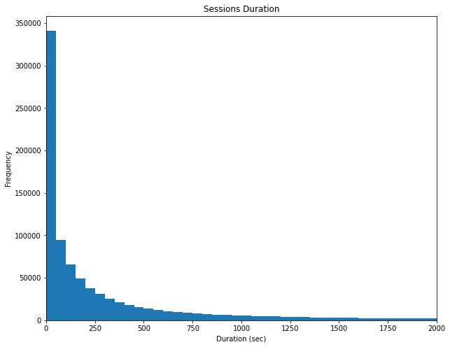

```python
sessions_duration = train.groupby('session_id', sort=False).timestamp.max() - train.groupby('session_id', sort=False).timestamp.min()
bin_size = 50
bin_edges = np.arange(0, 2000 + bin_size, bin_size)

plt.figure(figsize=[10, 8])
plt.hist(sessions_duration, bins=bin_edges)
plt.xlim([0, 2000])
plt.xlabel('Duration (sec)')
plt.ylabel('Frequency')
plt.title('Sessions Duration')
plt.show()
```

The data is right skewed. Logarithmic transformation would be much of a help in this case.

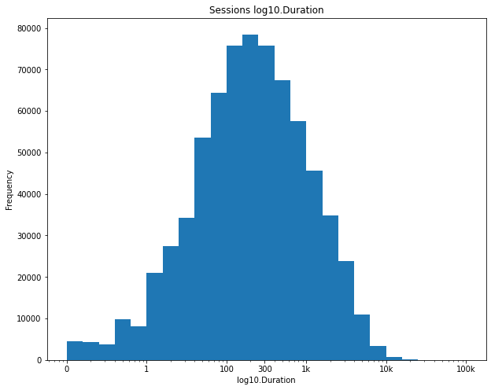

```python
bin_size = 0.2
bin_edges = 10 ** np.arange(0, 5 + bin_size, bin_size)

plt.figure(figsize=[10, 8])
plt.hist(sessions_duration, bins=bin_edges)
x_locs = [1e0, 1e1, 1e2, 3e2, 1e3, 1e4, 1e5]
x_labels = ['0', '1', '100', '300', '1k', '10k', '100k']
plt.xscale('log')
plt.xticks(x_locs, x_labels)
plt.xlabel('log10.Duration')
plt.ylabel('Frequency')
plt.title('Sessions log10.Duration')
plt.show()
```

**What is the action distribution?**

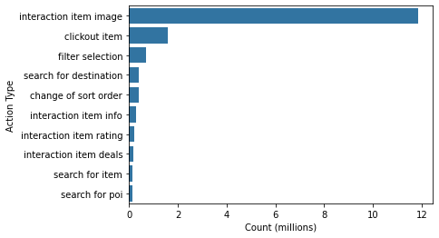

```python
action_type_order = train.action_type.value_counts().index
base_color = sns.color_palette()[0]
sns.countplot(data=train, y='action_type', color=base_color, order=action_type_order)
x_locs = [0, 0.2e7, 0.4e7, 0.6e7, 0.8e7, 1e7, 1.2e7]
x_labels = ['0', '2', '4', '6', '8', '10', '12']
plt.xlabel('Count (millions)')
plt.ylabel('Action Type')
plt.xticks(x_locs, x_labels)
plt.show()
```

It seems like users like to check for the images of the accommodations the most. Disregarding the 'interaction item image' to check the other attributes values. 'clickout item' comes second.

**What is the distribution of the platforms used?**

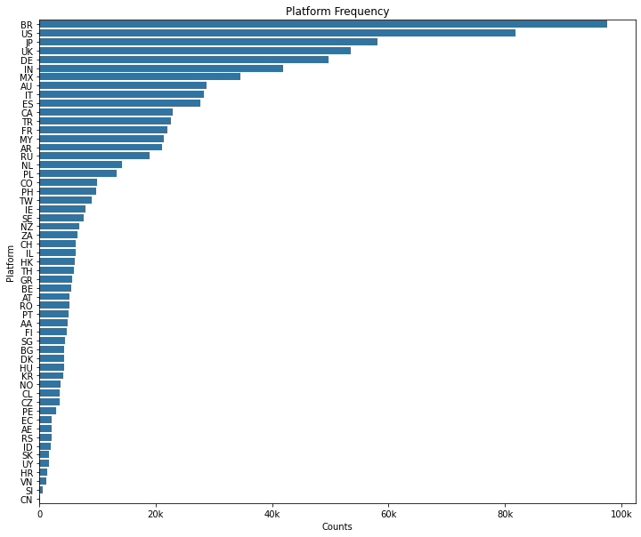

```python
clickout_df = train[train.action_type=='clickout item'].groupby('session_id', sort=False).tail(1)
base_color = sns.color_palette()[0]
platform_order = clickout_df.platform.value_counts().index
plt.figure(figsize=[12, 10])
sns.countplot(data=clickout_df, y='platform', color=base_color, order=platform_order)
plt.title('Platform Frequency')
plt.xlabel('Counts')
plt.ylabel('Platform')
x_locs = np.arange(0, 1e5 + 1, 2e4)
x_labels = ['0', '20k', '40k', '60k', '80k', '100k']
plt.xticks(x_locs, x_labels)
plt.show()
```

This shows that the highest number of users are from Brazil, comes second United States, and so on.

**What is the distribution of the worlds' accommodations selected?**

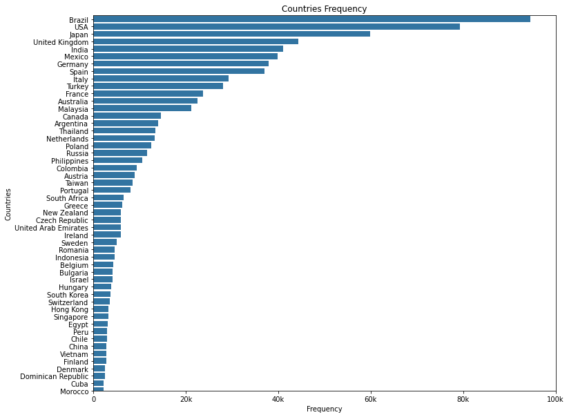

```python
countries = clickout_df.city.apply(lambda x: x.split(',')[1]).apply(lambda x: x.strip())
countries_order = countries.value_counts().index

plt.figure(figsize=[12, 10])
sns.countplot(y=countries, color=base_color, order=countries_order)
plt.ylim(50)
plt.xlabel('Frequency')
plt.ylabel('Countries')
plt.title('Countries Frequency')
x_locs = np.arange(0, 1e5 + 1, 2e4)
x_labels = ['0', '20k', '40k', '60k', '80k', '100k']
plt.xticks(x_locs, x_labels)
plt.show()
```

**How good is Trivago's Recommender Engine doing?**

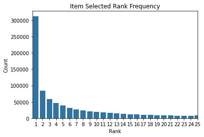

```python
sns.countplot(data=clickout_df, x='rank', color=base_color)
plt.xlim([0.5, 25])
plt.xlabel('Rank')
plt.ylabel('Count')
plt.title('Item Selected Rank Frequency');
```

```python
round(len(clickout_df[clickout_df['rank']==1])/len(clickout_df), 3)
```

```
0.378
```

It seems that Trivago's Recommender Engine is doing a good job since around 38% of the users are actually selecting the first item which is on the top of the list.

**What is the selected items' prices distribution?**

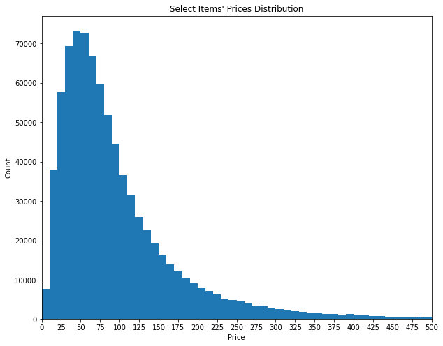

```python
clickout_df['price'] = clickout_df['price'].astype(int)

plt.figure(figsize=[10, 8])
bin_edges = np.arange(0, 510, 10)
plt.hist(clickout_df['price'], bins=bin_edges)
plt.xlim([0, 500])
plt.xticks([])
x_ticks = np.arange(0, 525, 25)
plt.xticks(x_ticks, x_ticks)
plt.xlabel('Price')
plt.ylabel('Count')
plt.title("Select Items' Prices Distribution");
```

**What is the relation between Rank and Average Step?**

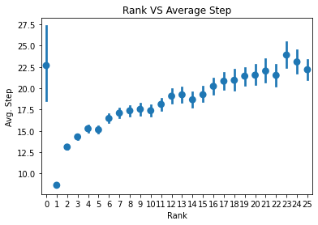

```python
sns.pointplot(data=clickout_df, x='rank', y='step', linestyles='')
plt.xlabel('Rank')
plt.ylabel('Avg. Step')
plt.title('Rank VS Average Step')
plt.show()
```

In general, this graph shows that the more the user takes step, the more likely they end up with an item that is not in the top of the list.  
The zero value of rank indicates that the choice of the user was not in the list in the first place. There might be a technical explanation for that such as the user was viewing from different tabs and the clickout was made from the tab that did no include the item.  
The large whisker in Zero means that there is no enough data available, for this point. On the other hand, the whisker keeps getting larger going from rank 1 to 25, that's because of the distribution of the data having rank 1 on the top for example.

**What is the relation between Rank and Average Step in the terms of devices?**

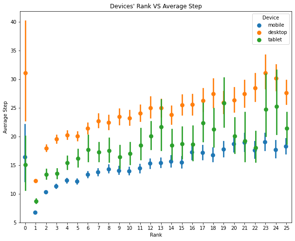

```python
plt.figure(figsize=[10, 8])
sns.pointplot(data=clickout_df, x='rank', y='step', hue='device', linestyles='', dodge=True)
plt.xlabel('Rank')
plt.ylabel('Average Step')
plt.legend(title='Device')
plt.title("Devices' Rank VS Average Step")
plt.show()
```

The relationship seems to be the same, only shifted when it comes to the device used. The desktop user makes more steps than the tablet and mobile user for the same rank, and the tablet user makes more steps than mobile user for the same rank.  
One explanation to this graph can be user feels more comfortable surfing the website on the desktop and takes their times checking accommodations than on smaller devices.

**What are the distributions of the mean price of the all show prices vs the selected prices?**

```python
clickout_df['prices_mean'] = clickout_df.prices.apply(lambda x: x.split('|'))\
                                               .apply(lambda x: list(map(int, x)))\
                                               .apply(lambda x: np.array(x).mean())\
                                               .apply(lambda x: np.floor(x))
```

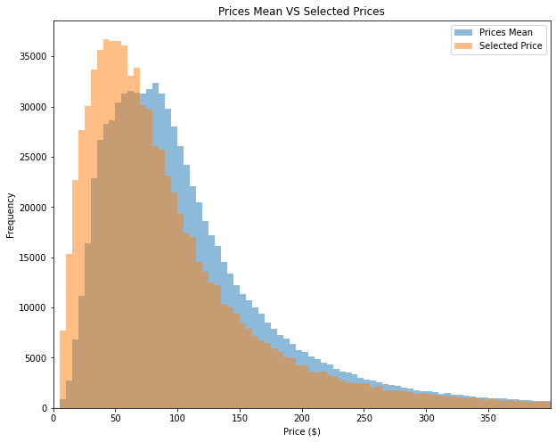

```python
bins = np.arange(0, 450, 5)
plt.figure(figsize=[10, 8])
plt.hist(clickout_df.prices_mean, bins=bins, alpha=0.5, label='Prices Mean')
plt.hist(clickout_df.price.astype(int), bins=bins, alpha=0.5, label='Selected Price')
plt.xlim([0, 400])
x_ticks = np.arange(0, 400, 50)
plt.xticks(x_ticks, x_ticks)
plt.title('Prices Mean VS Selected Prices')
plt.xlabel('Price ($)')
plt.ylabel('Frequency')
plt.legend()
plt.show()
```

The distribution of the prices of selected items by the user is shifted litle bit to the left and has higher height than that of the distribution of the mean of the prices. That shows that users in general would pick an item with price less than the mean price of all items shown to them.

**What are the distributions of the median of all prices shown to the users vs the selected prices?**

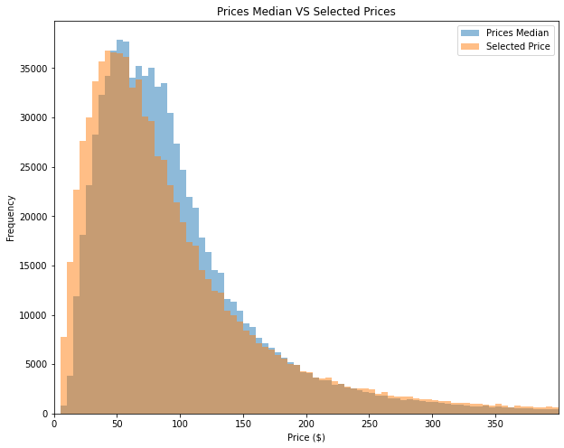

```python
bins = np.arange(0, 450, 5)
plt.figure(figsize=[10, 8])
plt.hist(clickout_df.prices_median, bins=bins, alpha=0.5, label='Prices Median')
plt.hist(clickout_df.price.astype(int), bins=bins, alpha=0.5, label='Selected Price')
plt.xlim([0, 400])
x_ticks = np.arange(0, 400, 50)
plt.xticks(x_ticks, x_ticks)
plt.title('Prices Median VS Selected Prices')
plt.xlabel('Price ($)')
plt.ylabel('Frequency')
plt.legend()
plt.show()
```